# COMP/STAT 112 Midterm Assessment

2024-03-25

# Instructions Etc.

**Begin by putting your name above as the author of this document**

You are to do this part of the assessment using `R` via `RStudio` on your computer.

- On this part of the assessment you may collaborate with others from our class. However each student will turn in their own `R Markdown` document with their own code and explanations.
- You are not required to work collaboratively with others, but, if you do, you must name the people you worked with in your turned-in solutions.
- You can work collaboratively with other COMP/STAT 112 student from this section. You can use any COMP/STAT 112 material from this semester. But you cannot use any other resources (e.g., internet, people outside this class, preceptors). You are *NOT* allowed to talk to anyone else outside of this class (section) about the problems or the solutions.
- You will submit the well-formatted html output of this `R Markdown` document of your work on Part II to Moodle by 3 pm on Wednesday, 27 March (tomorrow).

```r
# Load in the necessary packages

library(tidyverse)
library(mdsr)
```

# World Cities and Population

For this assessment you will work with three datasets

- the`world_cities` dataset available through the package `mdsr`,
- the `world_bank_pop` dataset which is part of the `tidyr` package,
- and the dataset `CountryCodes` which you will download in the next code chunk.

## Loading and Wrangling of the datasets

```r
# Loading and Wrangling the CountryCodes data

CountryCodes <- read_csv(
  "https://raw.githubusercontent.com/djoloughlin/Data/main/CountryCodes.csv") %>%
  rename(country2=`Alpha-2 code`,country3=`Alpha-3 code`) %>%
  arrange(country2)


head(CountryCodes)
```

```
## # A tibble: 6 × 4
##   Country                    country2 country3 Numeric
##   <chr>                      <chr>    <chr>      <dbl>
## 1 Andorra                    AD       AND           20
## 2 United Arab Emirates (the) AE       ARE          784
## 3 Afghanistan                AF       AFG            4
## 4 Antigua and Barbuda        AG       ATG           28
## 5 Anguilla                   AI       AIA          660
## 6 Albania                    AL       ALB            8
```

```r
# Wrangling the world_cities data

WorldCities<-world_cities %>%
  na.omit() %>%
  select(name,latitude,longitude,country,country_region,population,modification_date)

head(WorldCities)
```

```
## # A tibble: 6 × 7
##   name    latitude longitude country country_region population modification_date
##   <chr>      <dbl>     <dbl> <chr>   <chr>               <dbl> <date>
## 1 Ras Al…     25.8      55.9 AE      05                 351943 2019-09-09
## 2 Dubai       25.1      55.3 AE      03                2956587 2019-08-28
## 3 Sharjah     25.3      55.4 AE      06                1324473 2019-09-05
## 4 Ajman …     25.4      55.5 AE      02                 490035 2019-05-29
## 5 Abu Dh…     24.5      54.4 AE      01                 603492 2019-09-05
## 6 Musaff…     24.4      54.5 AE      01                 243341 2019-10-12
```

```r
WorldPopulation<-world_bank_pop %>%
  na.omit() %>%
  filter(indicator=="SP.POP.TOTL") %>%
  rename(Y2000=`2000`,Y2015=`2015`) %>%
  select(country,Y2000,Y2015)

head(WorldPopulation)
```

```
## # A tibble: 6 × 3
##   country     Y2000     Y2015
##   <chr>       <dbl>     <dbl>
## 1 ABW         89101    104257
## 2 AFE     401600588 600008150
## 3 AFG      19542982  33753499
## 4 AFW     269611898 408690375
## 5 AGO      16394062  28127721
## 6 ALB       3089027   2880703
```

# Problems

(each problem is worth 2 points for a total of 10)

## Problem 1

This is a warm-up problem. Using just the `WorldCities` wrangled data make a table of the largest Cities in the United states (the two character country code is “US”) by population, sorted from largest to smallest. Display the 20 largest Cities. Do you notice anything interesting about the cities that are listed (HINT: What are the five boroughs of NYC)? Also, say how many of these cities have more than 1 million people according to this data.

```r
LargestCitiesUS <- world_cities %>%
  filter(country == "US") %>%
  select(name,population) %>%
  arrange(desc(population))

millionCities <- LargestCitiesUS %>%
  filter(population>=1000000)
as.data.frame(LargestCitiesUS[1:20,])
```

```
##             name population
## 1  New York City    8175133
## 2    Los Angeles    3971883
## 3        Chicago    2720546
## 4       Brooklyn    2300664
## 5        Houston    2296224
## 6         Queens    2272771
## 7   Philadelphia    1567442
## 8        Phoenix    1563025
## 9      Manhattan    1487536
## 10   San Antonio    1469845
## 11     San Diego    1394928
## 12     The Bronx    1385108
## 13        Dallas    1300092
## 14      San Jose    1026908
## 15        Austin     931830
## 16  Jacksonville     868031
## 17 San Francisco     864816
## 18      Columbus     850106
## 19    Fort Worth     833319
## 20  Indianapolis     829718
```

```r
nrow(millionCities)
```

```
## [1] 14
```

New York has a few burrows listed, 14 cities with a population over 1 million

## Problem 2

Filter the `WorldCities` table to find information about the Twin Cities of “Minneapolis” and “Saint Paul”. Once you find their latitudes and longitudes, make a table of all cities in the Western Hemisphere that are within 1 degree of latitude from Minneapolis. Use the definition of the western hemisphere as longitudes between -160 degrees and -20 degrees. Where do Minneapolis and Saint Paul rank among these cities in terms of their population?

```r
twinCities <- WorldCities %>%
  filter(name == "Minneapolis" | name == "Saint Paul")

citiesLatitude <- WorldCities %>%
  filter(latitude <=45.97997 & latitude >= 43.97997 & longitude >=-160 & longitude<=-20) %>%
  arrange(desc(population))
```

## Problem 3

Note that the variable `country_region` in the `WorldCities` data gives the state in which the city is located for all US cities. How many US “states” are represented in this dataset? Are all of these “states” actually states?

Make a barplot where the bars represent data for US states and the heights of the bars are the number of cities in that state that have over 200,000 people. Show the top 20 states in this plot with the bars ordered from left to right in such a way that the left-most bar is for the state with the most such cities, and the next bar has the second most such cities, etc. The bars should be labeled by their two character state code, and the label on the x-axis of the plot should say `State`.

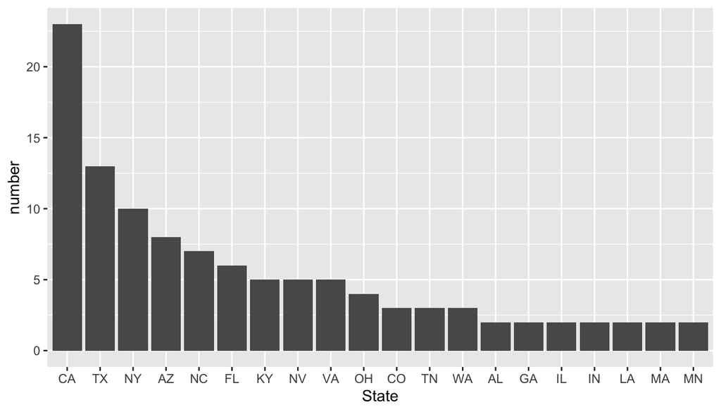

```r
statesData <- WorldCities %>%
  filter(country == "US",population >= 200000) %>%
  group_by(country_region) %>%
  summarize(number = n()) %>%
  arrange(desc(number))

top20 <-head(statesData,20)
ggplot(top20,aes(x=reorder(country_region,desc(number)),y = number)) +
  geom_col() + labs(x = "State")
```

Washington DC isnt a state, 45 states are observed

## Problem 4

For this problem you will need to use the `WorldPopulation` dataset and the `CountryCodes` dataset. First join the tables and replace the 3 character country code used in the `WorldPopulation` table with the full name of the country, then make a new variable, called `PctInc`, which represents the Percent increase in population from 2000 to 2015 for each country. Order this table from largest percent increase to smallest (most negative). The final table should have the country name, the populations for 2000 and 2015 and the percent increase in population over that time span. Give the top five and bottom five countries in terms of percent increase (or decrease) in population.

```r
updatedWorldPopulation <- WorldPopulation %>%
  left_join(CountryCodes, by = c('country' = 'country3')) %>%
  select(Country, Y2000, Y2015) %>%
  mutate(pctINC = ((Y2015 / Y2000) -1 )* 100) %>%
  arrange(desc(pctINC))

top5 <- head(updatedWorldPopulation,5)

bottom5 <-updatedWorldPopulation %>%
  arrange(pctINC)
head(bottom5,5)
```

```
## # A tibble: 5 × 4
##   Country                          Y2000   Y2015 pctINC
##   <chr>                            <dbl>   <dbl>  <dbl>
## 1 Northern Mariana Islands (the)   80338   51514  -35.9
## 2 Lithuania                      3499536 2904910  -17.0
## 3 Latvia                         2367550 1977527  -16.5
## 4 Bosnia and Herzegovina         4179350 3524324  -15.7
## 5 Bulgaria                       8170172 7177991  -12.1
```

## Problem 5

For this problem the first thing to do is add the country names to the `WorldCities` Table by joining information from the `CountryCodes` Table.

In this question we will explore cities that are at different latitudes or “zones”. We will define `Equatorial Cities` to be those within 10 degrees of the equator (i.e., -10 <= latitude <= 10) and `Polar Cities` to be those whose latitude is greater than or equal to 50 degrees or less than or equal to -50 degrees. Cities will be called `Tropical` Cities if they are between 10 and 30 degrees from the equator on either side, and `Temperate` if they are between 30 and 50 degrees from the equator on either side.

For each of these “zones”, make a table of the ten largest cities. Each of your tables should have the name of the city, its country, its population (as defined by this table), and its latitude. Also say how many cities are in each “zone”.

```r
updatedWorldCities <- WorldCities %>%
  left_join(CountryCodes, by = c('country' = 'country2')) %>%
  select(name,Country,longitude,latitude,population)

EquatorialCities<- updatedWorldCities %>%
  filter(latitude <= 10 & latitude>=-10) %>%
  arrange(desc(population))

nrow(EquatorialCities)
```

```
## [1] 544
```

```r
EquatorialCities10 <- head(EquatorialCities,10)


PolarCities<- updatedWorldCities %>%
  filter(latitude <= -50 | latitude>=50)%>%
  arrange(desc(population))

nrow(PolarCities)
```

```
## [1] 509
```

```r
PolarCities10 <- head(PolarCities,10)


TropicalCities<- updatedWorldCities %>%
  filter(latitude <= 30 & latitude>=10 | latitude <= -10 & latitude>=-30 ) %>%
  arrange(desc(population))

nrow(TropicalCities)
```

```
## [1] 1542
```

```r
TropicalCities10 <- head(TropicalCities,10)


TemperateCities<- updatedWorldCities %>%
  filter(latitude <= 50 & latitude>=30 | latitude <= -30 & latitude>=-50 ) %>%
  arrange(desc(population))

nrow(TemperateCities)
```

```
## [1] 1829
```

```r
TemperateCities10 <- head(TemperateCities,10)
```

# Finishing Up

Look back over your work and make sure you have answered every question. Make sure that you have formatted your code nicely and that your output is shown in the html output for the R Markdown. In the space below put the names of any other students from our section that you collaborated with

**I collaborated with: Mary and Sophia**

Then post your html output *AND ONLY YOUR HTML OUTPUT* to Moodle.